# NRENS DOCUMENTATION

## Task 1 :

Which ASes share the most traffic between them?

## First Approach to find the traffic in the Region:

```python
import pandas as pd
%matplotlib inline
import pandas as pd
import seaborn as sns
from matplotlib import pyplot as plt
import matplotlib as plt
import numpy as np
from pandas import DataFrame
import matplotlib.pyplot as plt
from sklearn.cluster import KMeans
```

```python
data1 = pd.read_csv("nren_as_mapping_cc.csv", encoding='latin-1')
```

```python
data1.head()
```

|  | AS Number | NREN | AS Rank | AS Neighbours | Organisation | AS customer cone | Number of paths | Relationship |
| --- | --- | --- | --- | --- | --- | --- | --- | --- |
| 0 | 1120 | ACONET Austria | 44784 | 14650 | NÃºcleo de Inf. e Coord. do Ponto BR - NIC.BR | 1 | 41 | customer |
| 1 | 1853 | ACONET Austria | 515 | 8501 | Institute of Bioorganic Chemistry Polish Acade... | 65 | 226 | customer |
| 2 | 1853 | ACONET Austria | 572 | 2607 | Zdruzenie pouzivatelov Slovenskej akademickej ... | 57 | 151 | customer |
| 3 | 1853 | ACONET Austria | 4476 | 30971 | nic.at GmbH | 4 | 225 | customer |
| 4 | 1853 | ACONET Austria | 4993 | 760 | Vienna University Computer Center | 3 | 263 | customer |

```python
rows,columns = data1.shape # exact shape of the dataset
```

```python
df=data1.drop(['AS Rank','AS Neighbours','Number of paths','Relationship'], axis=1) # Drop Columns as per need
```

```python
# applying groupby() function to
# group the data on team value
needed_data=df.groupby(['AS Number','Organisation'])

# Let's print the first entries
# in all the groups formed.
needed_data.first()
```

| AS Number | Organisation | NREN | AS customer cone |
| --- | --- | --- | --- |
| 137 | Area Science Park | GARR Italy | 1 |
|  | CONSORZIO TOP IX - TORINO E PIEMONTE EXCHANGE POINT CC | GARR Italy | 1 |
|  | CSP s.c. a r.l. | GARR Italy | 1 |
|  | Consiglio Nazionale delle Ricerche | GARR Italy | 1 |
|  | EFSA - European Food Safety Authority | GARR Italy | 1 |
| ... | ... | ... | ... |
| 396450 | University of Alabama at Birmingham | United States NREN | 1 |
|  | University of Chicago | United States NREN | 1 |
|  | University of Maryland | United States NREN | 44 |
|  | University of Missouri - dba the Missouri Research and Education Network (MOREnet) | United States NREN | 9 |
|  | University of Virginia | United States NREN | 1 |

1359 rows × 2 columns

#### Traffic According to the Region :

We have found the "Traffic" according to the sum of number of customers of a particular region. As mentioned in the documentation of this Customer Cones" https://www.caida.org/data/as-relationships/ " in this documentation we observed that a traffic in the organization or a region is the number of customers that are observed in the region or an organization.

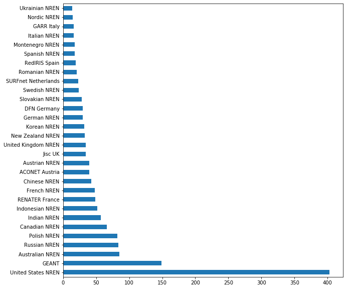

```python
# Graph Of the Traffic according to the number of counts of customers in the Region :
fig1=df['NREN'].value_counts()
fig1.head(30).plot(kind='barh',x='Value Of Counts Of Customers' ,y='Regions',figsize=(10,10))
```

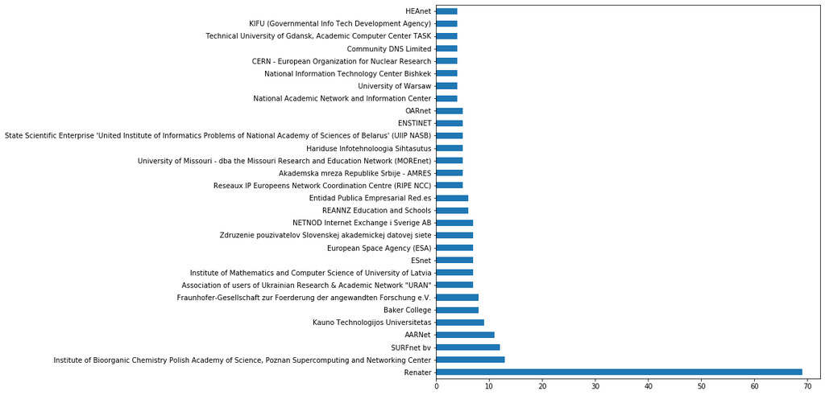

```python
# Graph Of the Traffic according to the number of counts of customers in the Region :
fig1=df['Organisation'].value_counts()
fig1.head(30).plot(kind='barh',x='Value Of Counts Of Customers' ,y='Organization',figsize=(10,10))
```

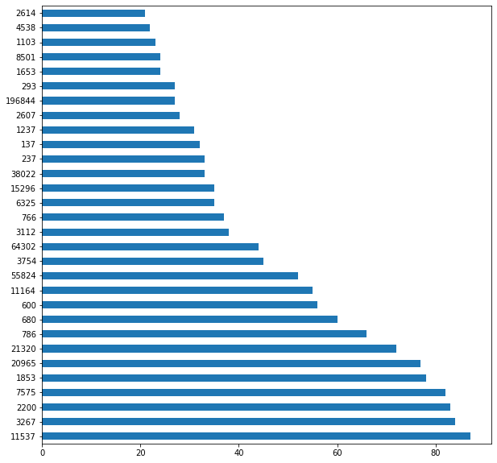

```python
# Graph Of the Traffic according to the number of counts of customers in the Region :
# For first 30 Rows :
fig2=df['AS Number'].value_counts()
fig2.head(30).plot(kind='barh',x='Value Of Counts Of Customers' ,y='As Number',figsize=(10,10))
```

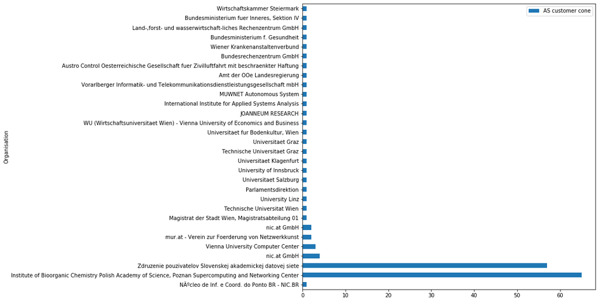

```python
# Graph Of the Traffic according to the number of customers in the Region :
# For first 30 Rows :
fig3=df.head(30)
fig3.plot(kind='barh',x='Organisation' ,y='AS customer cone',figsize=(10,10))
```

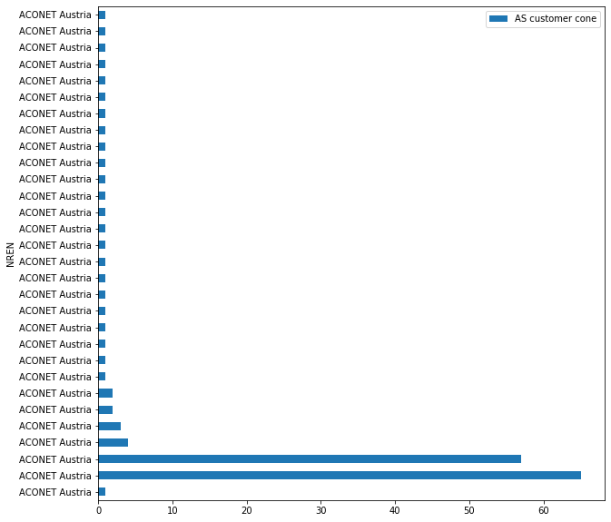

```python
# Graph Of the Traffic according to the number of customers in the Region :
# For first 30 Rows :
fig4=df.head(30)
fig4.plot(kind='barh',x='NREN' ,y='AS customer cone',figsize=(10,10))
```

## Second Approach to find that which ASes share the most traffic between them:

To accomplish this task we have added a new column "Band Width". In this column we have taken a sum of "Bytes" , "bps" , "Bpp" to identify the total bandwidth of each of the ASes. After finding the total bandwidth of each ASes we can identify the traffic shared between each ASes. After finding the traffic we can findout the most traffic shared.

```python
data2 = pd.read_csv("Aggregated_File.csv")
```

```python
data2.head(2)
```

|  | Date first | seen | Duration | Src AS | Dst AS | Packets | Bytes | bps | Bpp | Band Width | Flows |
| --- | --- | --- | --- | --- | --- | --- | --- | --- | --- | --- | --- |
| 0 | 14/02/2019 | 53:15.5 | 684.887 | 44224 | 11537 | 18300 | 190000000 | 222136 | 1039 | 190223175.0 | 26 |
| 1 | 14/02/2019 | 01:40.8 | 0.116 | 56665 | 2107 | 900 | 14000000 | 931000000 | 1500 | 945001500.0 | 1 |

```python
# Total Sum Of Bandwidth To Find the Mean Of Band Width
Total_Sum=data2['Band Width'].mean()
print(Total_Sum)
```

```
25820639508.211895
```

```python
# Finding the exact Traffic amount by measuring the Mean Bandwidth for a particular ASes
x=data2['Band Width'].div(Total_Sum)
```

```python
# Adding another Column in the dataset named as Traffic for making the exact Graphs for Traffic Flows
data2['Traffic']=x.apply(np.ceil)
```

```python
data2.head()
```

|  | Date first | seen | Duration | Src AS | Dst AS | Packets | Bytes | bps | Bpp | Band Width | Flows | Traffic |
| --- | --- | --- | --- | --- | --- | --- | --- | --- | --- | --- | --- | --- |
| 0 | 14/02/2019 | 53:15.5 | 684.887 | 44224 | 11537 | 18300 | 190000000 | 222136 | 1039 | 1.902232e+08 | 26 | 1.0 |
| 1 | 14/02/2019 | 01:40.8 | 0.116 | 56665 | 2107 | 900 | 14000000 | 931000000 | 1500 | 9.450015e+08 | 1 | 1.0 |
| 2 | 10/02/2019 | 26:00.8 | 301118.175 | 2200 | 5400 | 530400 | 1861000000 | 4944 | 350 | 1.861005e+09 | 844 | 1.0 |
| 3 | 14/02/2019 | 45:11.8 | 1175.931 | 513 | 16509 | 264300 | 941000000 | 640062 | 355 | 9.416404e+08 | 323 | 1.0 |
| 4 | 14/02/2019 | 07:30.7 | 10644.317 | 54113 | 2852 | 2.1 M | 29000000000 | 22000000 | 1356 | 2.902200e+10 | 1720 | 2.0 |

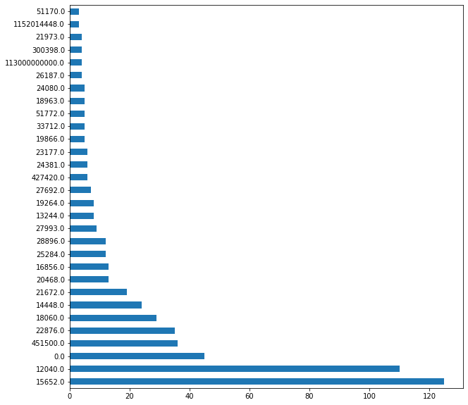

```python
# Graph Of the Traffic according to the number of counts of Bandwidth in Between the Src AS and Dst AS :
# For first 30 Rows :
# The X-axis point out the start 30 Counts of Bandwidth's
# The Y-axis point out the Value Counts Of the Band Width
fig5=data2['Band Width'].value_counts()
fig5.head(30).plot(kind='barh', figsize=(10,10))
```

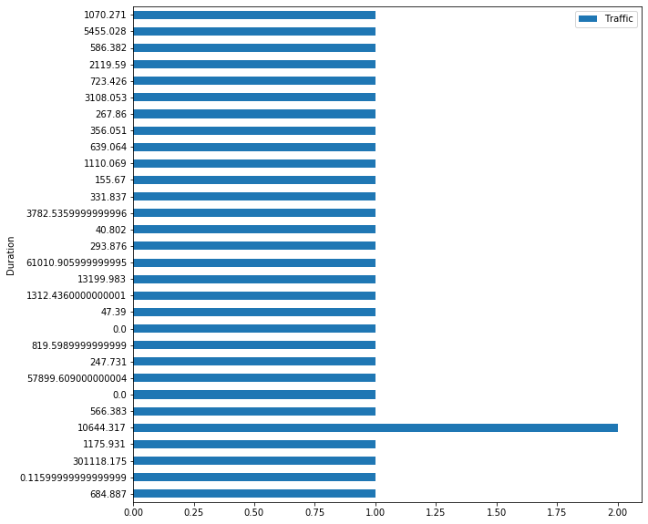

```python
# Graph Of the Traffic according to the Time Duration in between the Src AS and Dst AS :
# For first 30 Rows :
fig5=data2.head(30)
fig5.plot(kind='barh',x='Duration' ,y='Traffic',figsize=(10,10))
```

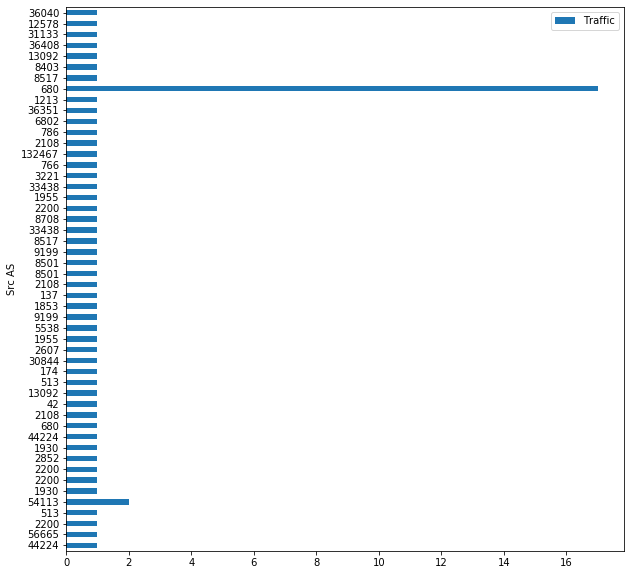

```python
# Graph Of the Traffic according to the Source AS:
# For first 50 Rows :
fig7=data2.head(50)
fig7.plot(kind='barh',x='Src AS' ,y='Traffic',figsize=(10,10))
```

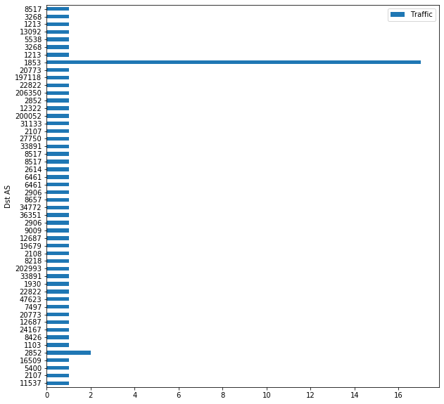

```python
# Graph Of the Traffic according to the Destination AS:
# For first 50 Rows :
fig8=data2.head(50)
fig8.plot(kind='barh',x='Dst AS' ,y='Traffic',figsize=(10,10))
```

In order to find out the details regarding most traffic as numbers, here is the function by which we can find the details of required as number

```python
def findMostTrafficAsDetails(asnumber):
    return data1.where(data1["AS Number"]== asnumber).dropna()
details = findMostTrafficAsDetails(680)
details
```

|  | AS Number | NREN | AS Rank | AS Neighbours | Organisation | AS customer cone | Number of paths | Relationship |
| --- | --- | --- | --- | --- | --- | --- | --- | --- |
| 51 | 680.0 | DFN Germany | 6489.0 | 12816.0 | Leibniz-Rechenzentrum | 2.0 | 425.0 | customer |
| 52 | 680.0 | DFN Germany | 6550.0 | 34878.0 | Karlsruhe Institute of Technology | 2.0 | 63.0 | customer |
| 53 | 680.0 | DFN Germany | 6768.0 | 199578.0 | Technische Universitaet Kaiserslautern | 2.0 | 295.0 | customer |
| 54 | 680.0 | DFN Germany | 10638.0 | 47610.0 | RWTH Aachen University | 1.0 | 221.0 | customer |
| 55 | 680.0 | DFN Germany | 10771.0 | 5501.0 | Fraunhofer-Gesellschaft zur Foerderung der ang... | 1.0 | 27.0 | customer |
| 56 | 680.0 | DFN Germany | 10896.0 | 1754.0 | Deutsches Elektronen-Synchrotron DESY | 1.0 | 214.0 | customer |
| 57 | 680.0 | DFN Germany | 10905.0 | 41289.0 | Deutscher Wetterdienst | 1.0 | 206.0 | customer |
| 58 | 680.0 | DFN Germany | 11348.0 | 12643.0 | Fraunhofer-Gesellschaft zur Foerderung der ang... | 1.0 | 15.0 | customer |
| 59 | 680.0 | DFN Germany | 11434.0 | 13167.0 | Merck KGaA | 1.0 | 60.0 | customer |
| 60 | 680.0 | DFN Germany | 11487.0 | 29484.0 | Ruhr-Universitaet Bochum | 1.0 | 42.0 | customer |
| 61 | 680.0 | DFN Germany | 11508.0 | 205046.0 | FZI Forschungszentrum Informatik am Karlsruher... | 1.0 | 138.0 | customer |
| 62 | 680.0 | DFN Germany | 11577.0 | 60344.0 | Asklepios Kliniken GmbH | 1.0 | 85.0 | customer |
| 63 | 680.0 | DFN Germany | 11740.0 | 20633.0 | Johann Wolfgang Goethe-Universitat Frankfurt a... | 1.0 | 66.0 | customer |
| 64 | 680.0 | DFN Germany | 11906.0 | 13040.0 | FIZ Karlsruhe - Leibniz-Institut fuer Informat... | 1.0 | 49.0 | customer |
| 65 | 680.0 | DFN Germany | 13673.0 | 49234.0 | Bundesamt fuer Sicherheit in der Informationst... | 1.0 | 147.0 | customer |
| 66 | 680.0 | DFN Germany | 13930.0 | 31705.0 | Europaischen Organisation fuer die Nutzung Met... | 1.0 | 211.0 | customer |
| 67 | 680.0 | DFN Germany | 14989.0 | 60824.0 | Fraunhofer-Gesellschaft zur Foerderung der ang... | 1.0 | 210.0 | customer |
| 68 | 680.0 | DFN Germany | 15202.0 | 12654.0 | Reseaux IP Europeens Network Coordination Cent... | 1.0 | 15.0 | customer |
| 69 | 680.0 | DFN Germany | 16522.0 | 8519.0 | European Space Agency (ESA) | 1.0 | 209.0 | customer |
| 70 | 680.0 | DFN Germany | 16522.0 | 20588.0 | Forschungsverbund Berlin e.V. | 1.0 | 211.0 | customer |
| 71 | 680.0 | DFN Germany | 16915.0 | 200943.0 | Fraunhofer-Gesellschaft zur Foerderung der ang... | 1.0 | 166.0 | customer |
| 72 | 680.0 | DFN Germany | 19806.0 | 43066.0 | Information und Technik Nordrhein-Westfalen | 1.0 | 243.0 | customer |
| 73 | 680.0 | DFN Germany | 21429.0 | 56357.0 | Technische Universitaet Muenchen | 1.0 | 213.0 | customer |
| 74 | 680.0 | DFN Germany | 24922.0 | 34520.0 | Deutsche Forschungsgemeinschaft e.V. | 1.0 | 101.0 | customer |
| 75 | 680.0 | DFN Germany | 24922.0 | 41955.0 | SerNet Service Network GmbH | 1.0 | 124.0 | customer |
| 76 | 680.0 | DFN Germany | 32732.0 | 203819.0 | European Space Agency (ESA) | 1.0 | 101.0 | customer |
| 77 | 680.0 | DFN Germany | 32732.0 | 205033.0 | Stadt Regensburg | 1.0 | 165.0 | customer |
| 78 | 680.0 | DFN Germany | 45946.0 | 6733.0 | DIMDI Deutsches Institut fuer medizinische Dok... | 1.0 | 37.0 | customer |
| 79 | 680.0 | DFN Germany | 45946.0 | 41969.0 | Rundfunk Berlin-Brandenburg RBB | 1.0 | 63.0 | customer |
| 80 | 680.0 | DFN Germany | 53436.0 | 47369.0 | Com Vision Betreibergesellschaft mbH | 1.0 | 75.0 | customer |
| 493 | 680.0 | German NREN | 6454.0 | 12816.0 | Leibniz-Rechenzentrum | 2.0 | 428.0 | customer |
| 494 | 680.0 | German NREN | 6518.0 | 34878.0 | Karlsruhe Institute of Technology | 2.0 | 89.0 | customer |
| 495 | 680.0 | German NREN | 6734.0 | 199578.0 | Technische Universitaet Kaiserslautern | 2.0 | 323.0 | customer |
| 496 | 680.0 | German NREN | 10558.0 | 47610.0 | RWTH Aachen University | 1.0 | 222.0 | customer |
| 497 | 680.0 | German NREN | 10696.0 | 5501.0 | Fraunhofer-Gesellschaft zur Foerderung der ang... | 1.0 | 28.0 | customer |
| 498 | 680.0 | German NREN | 10818.0 | 1754.0 | Deutsches Elektronen-Synchrotron DESY | 1.0 | 215.0 | customer |
| 499 | 680.0 | German NREN | 10826.0 | 41289.0 | Deutscher Wetterdienst | 1.0 | 204.0 | customer |
| 500 | 680.0 | German NREN | 11265.0 | 12643.0 | Fraunhofer-Gesellschaft zur Foerderung der ang... | 1.0 | 17.0 | customer |
| 501 | 680.0 | German NREN | 11351.0 | 13167.0 | Merck KGaA | 1.0 | 58.0 | customer |
| 502 | 680.0 | German NREN | 11410.0 | 29484.0 | Ruhr-Universitaet Bochum | 1.0 | 41.0 | customer |
| 503 | 680.0 | German NREN | 11431.0 | 205046.0 | FZI Forschungszentrum Informatik am Karlsruher... | 1.0 | 144.0 | customer |
| 504 | 680.0 | German NREN | 11497.0 | 60344.0 | Asklepios Kliniken GmbH | 1.0 | 85.0 | customer |
| 505 | 680.0 | German NREN | 11661.0 | 20633.0 | Johann Wolfgang Goethe-Universitat Frankfurt a... | 1.0 | 70.0 | customer |
| 506 | 680.0 | German NREN | 11829.0 | 13040.0 | FIZ Karlsruhe - Leibniz-Institut fuer Informat... | 1.0 | 50.0 | customer |
| 507 | 680.0 | German NREN | 13592.0 | 49234.0 | Bundesamt fuer Sicherheit in der Informationst... | 1.0 | 146.0 | customer |
| 508 | 680.0 | German NREN | 13844.0 | 31705.0 | Europaischen Organisation fuer die Nutzung Met... | 1.0 | 217.0 | customer |
| 509 | 680.0 | German NREN | 14907.0 | 60824.0 | Fraunhofer-Gesellschaft zur Foerderung der ang... | 1.0 | 208.0 | customer |
| 510 | 680.0 | German NREN | 15122.0 | 12654.0 | Reseaux IP Europeens Network Coordination Cent... | 1.0 | 16.0 | customer |
| 511 | 680.0 | German NREN | 16443.0 | 8519.0 | European Space Agency (ESA) | 1.0 | 208.0 | customer |
| 512 | 680.0 | German NREN | 16443.0 | 20588.0 | Forschungsverbund Berlin e.V. | 1.0 | 208.0 | customer |
| 513 | 680.0 | German NREN | 16842.0 | 200943.0 | Fraunhofer-Gesellschaft zur Foerderung der ang... | 1.0 | 171.0 | customer |
| 514 | 680.0 | German NREN | 19722.0 | 43066.0 | Information und Technik Nordrhein-Westfalen | 1.0 | 239.0 | customer |
| 515 | 680.0 | German NREN | 21359.0 | 56357.0 | Technische Universitaet Muenchen | 1.0 | 213.0 | customer |
| 516 | 680.0 | German NREN | 24849.0 | 41955.0 | SerNet Service Network GmbH | 1.0 | 117.0 | customer |
| 517 | 680.0 | German NREN | 24849.0 | 34520.0 | Deutsche Forschungsgemeinschaft e.V. | 1.0 | 98.0 | customer |
| 518 | 680.0 | German NREN | 32585.0 | 203819.0 | European Space Agency (ESA) | 1.0 | 98.0 | customer |
| 519 | 680.0 | German NREN | 32585.0 | 205033.0 | Stadt Regensburg | 1.0 | 156.0 | customer |
| 520 | 680.0 | German NREN | 45812.0 | 6733.0 | DIMDI Deutsches Institut fuer medizinische Dok... | 1.0 | 38.0 | customer |
| 521 | 680.0 | German NREN | 45812.0 | 41969.0 | Rundfunk Berlin-Brandenburg RBB | 1.0 | 63.0 | customer |
| 522 | 680.0 | German NREN | 53267.0 | 47369.0 | Com Vision Betreibergesellschaft mbH | 1.0 | 73.0 | customer |

## Task 2 :

Can we cluster ASes together in terms of attributes such as duration, traffic amount, packets and flows?

#### For performing task 2 we have applied KMeans Clusters

```python
df=data2.drop(['Date first','seen','Src AS','Dst AS','Bytes','bps','Bpp','Band Width'], axis=1) # Drop Columns as per need
```

```python
df
```

|  | Duration | Packets | Flows | Traffic |
| --- | --- | --- | --- | --- |
| 0 | 684.887 | 18300 | 26 | 1.0 |
| 1 | 0.116 | 900 | 1 | 1.0 |
| 2 | 301118.175 | 530400 | 844 | 1.0 |
| 3 | 1175.931 | 264300 | 323 | 1.0 |
| 4 | 10644.317 | 2.1 M | 1720 | 2.0 |
| ... | ... | ... | ... | ... |
| 6923 | 475.809 | 64500 | 133 | 1.0 |
| 6924 | 0.000 | 300 | 1 | 1.0 |
| 6925 | 0.000 | 300 | 1 | 1.0 |
| 6926 | 333.081 | 12600 | 9 | 1.0 |
| 6927 | 0.000 | 300 | 1 | 1.0 |

6928 rows × 4 columns

```
[[ 4.41612563e+03  1.75796551e+00]
 [ 1.63563949e+06 -4.44089210e-16]
 [ 2.96451870e+06  6.66133815e-16]
 [ 5.30975931e+05  2.83720930e+01]]
```

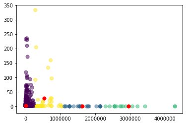

```python
# For Making a cluster we have to select the attributes on which we are making a cluster
# In this cluster we are selecting 2 columns 'Duration' & 'Traffic'
# In this cluster we are making the relation between 'Time Duration' and 'Traffic Amount'

cluster1=df.drop(['Packets','Flows'],axis=1)
kmeans = KMeans(n_clusters=4).fit(cluster1)
centroids = kmeans.cluster_centers_
print(centroids)

plt.scatter(cluster1['Duration'], cluster1['Traffic'], c= kmeans.labels_.astype(float), s=50, alpha=0.5)
plt.scatter(centroids[:, 0], centroids[:, 1], c='red', s=50)
plt.show()
```

```
[[4.41612563e+03 3.66190295e+02]
 [2.96451870e+06 4.76374375e+04]
 [1.63563949e+06 6.55248889e+04]
 [5.30975931e+05 8.57072093e+03]]
```

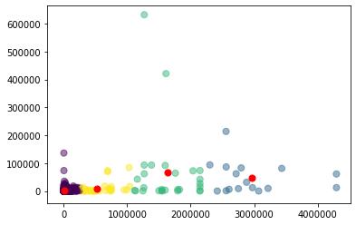

```python
# For Making a cluster we have to select the attributes on which we are making a cluster
# In this cluster we are selecting 2 columns 'Duration' & 'Flows'
# In this cluster we are making the relation between 'Time Duration' and 'Flows'

cluster2=df.drop(['Traffic','Packets'],axis=1)
kmeans = KMeans(n_clusters=4).fit(cluster2)
centroids = kmeans.cluster_centers_
print(centroids)

plt.scatter(cluster2['Duration'], cluster2['Flows'], c= kmeans.labels_.astype(float), s=50, alpha=0.5)
plt.scatter(centroids[:, 0], centroids[:, 1], c='red', s=50)
plt.show()
```

```
[[3.88674533e+02 1.90951209e+00]
 [6.32370000e+05 0.00000000e+00]
 [4.21161000e+05 0.00000000e+00]
 [8.77515789e+04 3.10526316e+00]]
```

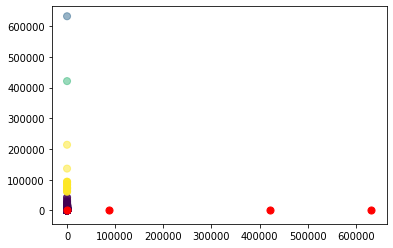

```python
# For Making a cluster we have to select the attributes on which we are making a cluster
# In this cluster we are selecting 2 columns 'Traffic' & 'Flows'
# In this cluster we are making the relation between 'Traffic Amount' and 'Flows'


cluster3=df.drop(['Duration','Packets'],axis=1)
kmeans = KMeans(n_clusters=4).fit(cluster3)
centroids = kmeans.cluster_centers_
print(centroids)

plt.scatter(cluster3['Traffic'], cluster3['Flows'], c= kmeans.labels_.astype(float), s=50, alpha=0.5)
plt.scatter(centroids[:, 0], centroids[:, 1], c='red', s=50)
plt.show()
```

## Task 3 :

Which BGP hops are the most popular next hops transits?

```python
data = pd.read_csv("BGP_Task.csv", index_col = False)
```

```python
data
```

|  | Duration | Protocol | Exp ID | Src IP Addr | Dst IP Addr | Src Pt | Dst Pt | Next-hop IP | BGP next-hop IP | Router IP | Src AS | Dst AS | Input | Output | Packets | Bytes |
| --- | --- | --- | --- | --- | --- | --- | --- | --- | --- | --- | --- | --- | --- | --- | --- | --- |
| 0 | 135.379 | 6 | 22 | 118.106.239.234 | 51.57.63.222 | 55922 | 46196.0 | 62.40.98.68 | 62.40.124.198 | 62.40.96.26 | 680 | 786 | 606 | 573 | 300 | 15600 |
| 1 | 0.000 | 6 | 22 | 119.45.33.73 | 119.94.169.231 | 34416 | 9626.0 | 62.40.98.68 | 62.40.97.11 | 62.40.96.26 | 680 | 293 | 608 | 573 | 300 | 19500 |
| 2 | 1.493 | 6 | 22 | 119.45.35.127 | 66.186.24.208 | 48666 | 1095.0 | 62.40.98.68 | 62.40.97.14 | 62.40.96.26 | 680 | 513 | 608 | 573 | 1800 | 93600 |
| 3 | 659.846 | 6 | 22 | dffe:c6..f:fe:79 | 2081:cb..:ffff:0 | 39514 | 52641.0 | fe80::a..42:dfc1 | :: | 62.40.96.26 | 680 | 3221 | 606 | 635 | 346800 | 520200000 |
| 4 | 9.162 | 6 | 22 | 48.37.189.237 | 120.16.55.37 | 11483 | 21.0 | 62.40.98.68 | 62.40.124.2 | 62.40.96.26 | 680 | 1853 | 606 | 573 | 600 | 33000 |
| ... | ... | ... | ... | ... | ... | ... | ... | ... | ... | ... | ... | ... | ... | ... | ... | ... |
| 1048570 | 0.000 | 6 | 15 | 194.59.209.150 | 93.158.84.73 | 53955 | 23.0 | 83.97.88.6 | 83.97.88.6 | 62.40.97.1 | 1299 | 13092 | 899 | 876 | 300 | 12000 |
| 1048571 | 251.991 | 6 | 15 | 15fd:da..35:9298 | df81:38..90:f417 | 443 | 51641.0 | 2001:798:1::66 | :: | 62.40.97.1 | 2603 | 1955 | 1002 | 705 | 600 | 900000 |
| 1048572 | 0.000 | 6 | 15 | 48.166.1.169 | 238.51.55.83 | 35516 | 993.0 | 62.40.98.47 | 62.40.97.12 | 62.40.97.1 | 1955 | 714 | 705 | 770 | 300 | 15600 |
| 1048573 | 132.996 | 6 | 15 | 108.242.30.84 | 49.18.4.167 | 80 | 2607.0 | 62.40.98.45 | 62.40.96.21 | 62.40.97.1 | 174 | 6802 | 1002 | 714 | 300 | 447600 |
| 1048574 | 0.000 | 58 | 15 | dffe:38..ff:ff:5 | 2a83:28..:0:fd13 | 0 | 128.0 | 2001:20..14f2::1 | :: | 62.40.97.1 | 20965 | 1299 | 631 | 899 | 300 | 24000 |

1048575 rows × 16 columns

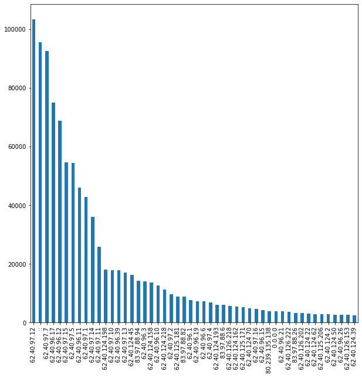

```python
# Graph Of the Most Popular BGP next-hop Transit according to the number of counts of Most Common BGP next-hop IP :
# The X-axis point out the start 50 BGP next-hop IP's
# The Y-axis point out the most Common out comes of the BGP IP's
dt=data['BGP next-hop IP '].value_counts()
dt.head(50).plot(kind='bar',x='BGP next-hop IP' ,y='Value Counts Of Most Common BGP next-hop IP', figsize=(10,10))
```

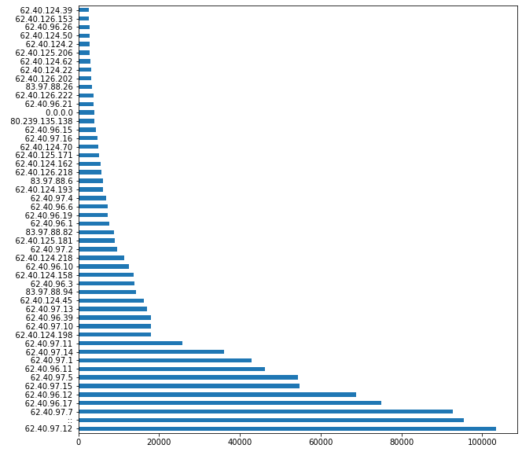

```python
# Graph Of the Most Popular BGP next-hop Transit according to the number of counts of Most Common BGP next-hop IP :
# The X-axis point out the start 50 BGP next-hop IP's
# The Y-axis point out the most Common out comes of the BGP IP's
dt=data['BGP next-hop IP '].value_counts()
dt.head(50).plot(kind='barh',x='BGP next-hop IP' ,y='Value Counts Of Most Common BGP next-hop IP', figsize=(10,10))
```